# northeastScaniadatabase

```python
%load_ext autoreload
%autoreload 3
```

%load_ext autoreload %autoreload 3

```
The autoreload extension is already loaded. To reload it, use:
  %reload_ext autoreload
```

```python
# Python 3.11.2
from funct_process_data import *  # Import all functions from funct_process_data.py
%matplotlib inline
```

# Python 3.11.2 from funct_process_data import * # Import all functions from funct_process_data.py %matplotlib inline

We have three different data sources.

1. The data collected by Bodil corresponds to the plague period.
2. The data provided by Lennart Palm which contains the population size for each parish in 1699 and 1718 based on a combination of tax records and estimations of population totals for Scania.
3. The geographical information (polygons) for some parishes. This information doesn't correspond to the plague period.

Our goal is to create a unique database for our project: Plague spread across Scania, Sweden, from 1710 to 1715.

1. We start working with Bodil's information which we store in two databases: One database corresponds to the parishes affected by the plague, the region where parishes are located in Scania, the beginning and end of the outbreaks, and the number of victims. The second database corresponds to all the parishes in Scania during the plague period, the district, and the region they belonged to.

The goal is to merge these two databases. First we set the working directory for private and public files.

```python
# For public files paths
data_folder = "data"
appendix6_path = os.path.join(data_folder, "Appendix6Bodil.csv")

# For private files paths
data_private_folder = "data/private"
allParishes_path = os.path.join(data_private_folder, "allParishesScania.xlsx")
```

# For public files paths data_folder = "data" appendix6_path = os.path.join(data_folder, "Appendix6Bodil.csv") # For private files paths data_private_folder = "data/private" allParishes_path = os.path.join(data_private_folder, "allParishesScania.xlsx")

Reading the different data sources (.xlsx, and .csv files)

```python
# Bodil's data Appendix 6 plague parishes
plagueParishesScania = pd.read_csv(appendix6_path, sep=",", encoding="utf-8")

# All parishes from the Southwest Scania with population data from Lennart Palm file
northeastScania = pd.read_excel(allParishes_path, sheet_name="northeast")
```

# Bodil's data Appendix 6 plague parishes plagueParishesScania = pd.read_csv(appendix6_path, sep=",", encoding="utf-8") # All parishes from the Southwest Scania with population data from Lennart Palm file northeastScania = pd.read_excel(allParishes_path, sheet_name="northeast")

Transforming the lowercase to uppercase and checking the type

```python
plagueParishesScania = plagueParishesScania.apply(
    lambda x: x.astype(str).str.upper())
northeastScania = northeastScania.apply(
    lambda x: x.astype(str).str.upper())
```

plagueParishesScania = plagueParishesScania.apply( lambda x: x.astype(str).str.upper()) northeastScania = northeastScania.apply( lambda x: x.astype(str).str.upper())

Merging the two datasets (northeastScania and plagueParishesScania)

```python
northeastParishesPop = pd.merge(
    northeastScania, plagueParishesScania, how='left', on=['ParishName', 'Region'])
```

northeastParishesPop = pd.merge( northeastScania, plagueParishesScania, how='left', on=['ParishName', 'Region'])

```python
northeastParishesPop.loc[0:20]
```

northeastParishesPop.loc[0:20]

|  | Region | District(Härad) | ParishName | BEF1699 | BEF1718 | AV_BEF | ChurchBook | OtherSources | BeginPlaguePeriod | EndPlaguePeriod | VictimsNumber |
| --- | --- | --- | --- | --- | --- | --- | --- | --- | --- | --- | --- |
| 0 | NORTHEAST | GÄRDS | DEGEBERGA | 463 | 523 | 493.0 | 2 | 5 | NaN | NaN | NaN |
| 1 | NORTHEAST | GÄRDS | DJURRÖD | 327 | 369 | 348.0 | 2 | 5 | NaN | NaN | NaN |
| 2 | NORTHEAST | GÄRDS | EVERÖD | 362 | 409 | 385.5 | 2 | 5 | NaN | NaN | NaN |
| 3 | NORTHEAST | GÄRDS | HUARÖD | 342 | 386 | 364.0 | 2 | 5 | NaN | NaN | NaN |
| 4 | NORTHEAST | GÄRDS | HÖRRÖD | 258 | 291 | 274.5 | 3 | 5 | NaN | NaN | NaN |
| 5 | NORTHEAST | GÄRDS | KÖPINGE | 644 | 727 | 685.5 | 3 | 5 | NaN | NaN | NaN |
| 6 | NORTHEAST | GÄRDS | LINDERÖD | 318 | 359 | 338.5 | 3 | 5 | NaN | NaN | NaN |
| 7 | NORTHEAST | GÄRDS | LYNGSJÖ | 224 | 253 | 238.5 | 3 | 5 | NaN | NaN | NaN |
| 8 | NORTHEAST | GÄRDS | MAGLEHEM | 477 | 538 | 507.5 | 3 | 5 | NaN | NaN | NaN |
| 9 | NORTHEAST | GÄRDS | NORRA ÅSUM | 522 | 589 | 555.5 | 3 | 4 | OCT 1711 | FEB 1712 | ? |
| 10 | NORTHEAST | GÄRDS | SKEPPARSLÖV | 409 | 462 | 435.5 | 3 | 4 | OCT 1711 | UNDEFINED | 5 |
| 11 | NORTHEAST | GÄRDS | TRÄNE | 474 | 535 | 504.5 | 2 | 4 | OCT 1711 | MAR 1712 | 40 |
| 12 | NORTHEAST | GÄRDS | VITTSKÖVLE | 639 | 721 | 680.0 | 2 | 5 | NaN | NaN | NaN |
| 13 | NORTHEAST | GÄRDS | VÄ | 556 | 628 | 592.0 | 1 | 5 | NOV 1711 | JAN 1712 | 55 |
| 14 | NORTHEAST | GÄRDS | VÄSTRA VRAM | 673 | 759 | 716.0 | 2 | 4 | DEC 1710 | JAN 1711 | 18 |
| 15 | NORTHEAST | GÄRDS | ÄSPHULT | 418 | 472 | 445.0 | 3 | 5 | NaN | NaN | NaN |
| 16 | NORTHEAST | GÄRDS | ÖSTRA SÖNNARSLÖV | 582 | 656 | 619.0 | 2 | 5 | NaN | NaN | NaN |
| 17 | NORTHEAST | GÄRDS | ÖSTRA VRAM | 128 | 144 | 136.0 | 2 | 5 | NaN | NaN | NaN |
| 18 | NORTHEAST | GÖINGE VÄSTRA | BRÖNNESTAD | 550 | 620 | 585.0 | 2 | 5 | NaN | NaN | NaN |
| 19 | NORTHEAST | GÖINGE VÄSTRA | FARSTORP | 436 | 492 | 464.0 | 2 | 5 | NaN | NaN | NaN |
| 20 | NORTHEAST | GÖINGE VÄSTRA | FINJA | 403 | 455 | 429.0 | 2 | 5 | NaN | NaN | NaN |

Extracting the parishes' names from the data frame

```python
parishesNortheastScania_names = get_Names(
    northeastParishesPop, 'ParishName').unique().tolist()
len(parishesNortheastScania_names)
```

parishesNortheastScania_names = get_Names( northeastParishesPop, 'ParishName').unique().tolist() len(parishesNortheastScania_names)

```
71
```

2. The geographical information for Scania is already projected on the plane, i.e. the measures are in meters not in longitude and latitude. To process the shape file, we set the directory and chose the columns to work with.

```python
# Get the current working directory
data_folder = "MapScaniaSweden"
parishScania_path = os.path.join(data_folder, "Parishes1720_1890.shp")
SkaneMap_path = os.path.join(data_folder, "Skane1720_1890.shp")

SkaneMap = gpd.read_file(SkaneMap_path)
parishScaniaMap = gpd.read_file(parishScania_path)
selected_columns = ['G_NAME', 'GET_START_', 'GET_END_YE', 'geometry']
SkaneMap = SkaneMap[selected_columns]
parishScaniaMap = parishScaniaMap[selected_columns]
```

# Get the current working directory data_folder = "MapScaniaSweden" parishScania_path = os.path.join(data_folder, "Parishes1720_1890.shp") SkaneMap_path = os.path.join(data_folder, "Skane1720_1890.shp") SkaneMap = gpd.read_file(SkaneMap_path) parishScaniaMap = gpd.read_file(parishScania_path) selected_columns = ['G_NAME', 'GET_START_', 'GET_END_YE', 'geometry'] SkaneMap = SkaneMap[selected_columns] parishScaniaMap = parishScaniaMap[selected_columns]

```python
parishScaniaMap = replace_strings_and_regex(parishScaniaMap, 'G_NAME', [' FÖRSAMLING', ' L LÄN', ' S LÄN', ' M LÄN', ' HELIGA TREFALDIGHETS', ' LANDSFÖRSAMLING', ' STADS', ' LANDS', ' SKÅNES'
                                                                    ])
```

parishScaniaMap = replace_strings_and_regex(parishScaniaMap, 'G_NAME', [' FÖRSAMLING', ' L LÄN', ' S LÄN', ' M LÄN', ' HELIGA TREFALDIGHETS', ' LANDSFÖRSAMLING', ' STADS', ' LANDS', ' SKÅNES' ])

```python
df1 = northeastParishesPop
df2 = parishScaniaMap

df_matches = fuzzy_match(
    df1,
    df2,
    'ParishName',
    'G_NAME',
    threshold=90,
    limit=1
)

df_output = df1.merge(
    df_matches,
    how='left',
    left_index=True,
    right_on='df_left_id'
).merge(
    df2,
    how='left',
    left_on='df_right_id',
    right_index=True,
    suffixes=['_df1', '_df2']
)

# For some reason the first merge operation wrecks the dataframe's index. Recreated from the value we have in the matches lookup table
df_output.set_index('df_left_id', inplace=True)

# df_output = df_output[['col_a_df1', 'col_b_df1', 'col_b_df2']]      # Drop columns used in the matching
df_output.index.name = 'id'
```

df1 = northeastParishesPop df2 = parishScaniaMap df_matches = fuzzy_match( df1, df2, 'ParishName', 'G_NAME', threshold=90, limit=1 ) df_output = df1.merge( df_matches, how='left', left_index=True, right_on='df_left_id' ).merge( df2, how='left', left_on='df_right_id', right_index=True, suffixes=['_df1', '_df2'] ) # For some reason the first merge operation wrecks the dataframe's index. Recreated from the value we have in the matches lookup table df_output.set_index('df_left_id', inplace=True) # df_output = df_output[['col_a_df1', 'col_b_df1', 'col_b_df2']] # Drop columns used in the matching df_output.index.name = 'id'

```python
northeastParishMap = df_output[[
    'Region', 'District(Härad)', 'ParishName', 'G_NAME', 'BEF1699'
    , 'BEF1718', 'AV_BEF', 'ChurchBook', 'OtherSources', 'BeginPlaguePeriod'
    , 'EndPlaguePeriod', 'VictimsNumber', 'geometry']]
```

northeastParishMap = df_output[[ 'Region', 'District(Härad)', 'ParishName', 'G_NAME', 'BEF1699' , 'BEF1718', 'AV_BEF', 'ChurchBook', 'OtherSources', 'BeginPlaguePeriod' , 'EndPlaguePeriod', 'VictimsNumber', 'geometry']]

```python
northeastParishMap.loc[0:20]
```

northeastParishMap.loc[0:20]

| id | Region | District(Härad) | ParishName | G_NAME | BEF1699 | BEF1718 | AV_BEF | ChurchBook | OtherSources | BeginPlaguePeriod | EndPlaguePeriod | VictimsNumber | geometry |
| --- | --- | --- | --- | --- | --- | --- | --- | --- | --- | --- | --- | --- | --- |
| 0 | NORTHEAST | GÄRDS | DEGEBERGA | DEGEBERGA | 463 | 523 | 493.0 | 2 | 5 | NaN | NaN | NaN | POLYGON ((4242432.518 3216403.674, 4242587.452... |
| 1 | NORTHEAST | GÄRDS | DJURRÖD | DJURRÖDS | 327 | 369 | 348.0 | 2 | 5 | NaN | NaN | NaN | POLYGON ((4235034.141 3239316.925, 4235277.475... |
| 2 | NORTHEAST | GÄRDS | EVERÖD | EVERÖDS | 362 | 409 | 385.5 | 2 | 5 | NaN | NaN | NaN | POLYGON ((4244852.781 3223435.169, 4244763.383... |
| 3 | NORTHEAST | GÄRDS | HUARÖD | HUARÖDS | 342 | 386 | 364.0 | 2 | 5 | NaN | NaN | NaN | POLYGON ((4242432.518 3216403.674, 4242367.213... |
| 4 | NORTHEAST | GÄRDS | HÖRRÖD | NaN | 258 | 291 | 274.5 | 3 | 5 | NaN | NaN | NaN | None |
| 5 | NORTHEAST | GÄRDS | KÖPINGE | KÖPINGE | 644 | 727 | 685.5 | 3 | 5 | NaN | NaN | NaN | POLYGON ((4255464.917 3230813.998, 4255408.599... |
| 6 | NORTHEAST | GÄRDS | LINDERÖD | LINDERÖDS | 318 | 359 | 338.5 | 3 | 5 | NaN | NaN | NaN | POLYGON ((4227839.808 3230701.940, 4228280.140... |
| 7 | NORTHEAST | GÄRDS | LYNGSJÖ | LYNGSJÖ | 224 | 253 | 238.5 | 3 | 5 | NaN | NaN | NaN | POLYGON ((4245353.997 3229661.393, 4245321.119... |
| 8 | NORTHEAST | GÄRDS | MAGLEHEM | MAGLEHEMS | 477 | 538 | 507.5 | 3 | 5 | NaN | NaN | NaN | POLYGON ((4251987.638 3216821.325, 4252685.190... |
| 9 | NORTHEAST | GÄRDS | NORRA ÅSUM | NORRA ÅSUMS | 522 | 589 | 555.5 | 3 | 4 | OCT 1711 | FEB 1712 | ? | POLYGON ((4249757.034 3241445.338, 4249865.346... |
| 10 | NORTHEAST | GÄRDS | SKEPPARSLÖV | SKEPPARSLÖVS | 409 | 462 | 435.5 | 3 | 4 | OCT 1711 | UNDEFINED | 5 | POLYGON ((4241776.825 3239062.212, 4241471.416... |
| 11 | NORTHEAST | GÄRDS | TRÄNE | TRÄNE | 474 | 535 | 504.5 | 2 | 4 | OCT 1711 | MAR 1712 | 40 | POLYGON ((4241776.825 3239062.212, 4241952.361... |
| 12 | NORTHEAST | GÄRDS | VITTSKÖVLE | VITTSKÖVLE | 639 | 721 | 680.0 | 2 | 5 | NaN | NaN | NaN | POLYGON ((4251987.638 3216821.325, 4252069.239... |
| 13 | NORTHEAST | GÄRDS | VÄ | VÄ | 556 | 628 | 592.0 | 1 | 5 | NOV 1711 | JAN 1712 | 55 | POLYGON ((4246916.116 3231887.997, 4247067.301... |
| 14 | NORTHEAST | GÄRDS | VÄSTRA VRAM | VÄSTRA VRAMS | 673 | 759 | 716.0 | 2 | 4 | DEC 1710 | JAN 1711 | 18 | POLYGON ((4237203.042 3227245.029, 4236492.276... |
| 15 | NORTHEAST | GÄRDS | ÄSPHULT | ÄSPHULTS | 418 | 472 | 445.0 | 3 | 5 | NaN | NaN | NaN | POLYGON ((4227839.808 3230701.940, 4228155.888... |
| 16 | NORTHEAST | GÄRDS | ÖSTRA SÖNNARSLÖV | ÖSTRA SÖNNARSLÖVS | 582 | 656 | 619.0 | 2 | 5 | NaN | NaN | NaN | POLYGON ((4244852.781 3223435.169, 4245130.252... |
| 17 | NORTHEAST | GÄRDS | ÖSTRA VRAM | ÖSTRA VRAMS | 128 | 144 | 136.0 | 2 | 5 | NaN | NaN | NaN | POLYGON ((4245961.839 3231295.748, 4246056.931... |
| 18 | NORTHEAST | GÖINGE VÄSTRA | BRÖNNESTAD | BRÖNNESTADS | 550 | 620 | 585.0 | 2 | 5 | NaN | NaN | NaN | POLYGON ((4225492.274 3250504.084, 4225598.126... |
| 19 | NORTHEAST | GÖINGE VÄSTRA | FARSTORP | FARSTORPS | 436 | 492 | 464.0 | 2 | 5 | NaN | NaN | NaN | POLYGON ((4233766.998 3266498.553, 4233697.441... |
| 20 | NORTHEAST | GÖINGE VÄSTRA | FINJA | FINJA | 403 | 455 | 429.0 | 2 | 5 | NaN | NaN | NaN | POLYGON ((4221889.882 3259320.758, 4222291.452... |

After checking the previous data, we found some issues when we assign the polygons to HÖRROD (4), FARLÖV(42), GRYT (44), and NÄSUM (64 and 65). We will modify the geographical data for these parishes using the indexes and the shape file.

```python
# Check the index of the parish that is not matched
northeastParishMap.loc[northeastParishMap['ParishName'] == 'HÖRRÖD']
northeastParishMap.loc[northeastParishMap['ParishName'] == 'FÄRLÖV']
northeastParishMap.loc[northeastParishMap['ParishName'] == 'GRYT']
northeastParishMap.loc[northeastParishMap['ParishName'] == 'NÄSUM']

# Check the correct geographical information in the shapefile
parishScaniaMap.loc[parishScaniaMap['G_NAME'] == 'HÖRRÖDS']
parishScaniaMap.loc[(parishScaniaMap['G_NAME'] == 'FÄRLÖVS')
                    & (parishScaniaMap['GET_START_'] == 1707)]
parishScaniaMap.loc[parishScaniaMap['G_NAME'] == 'GRYTS']
parishScaniaMap.loc[(parishScaniaMap['G_NAME'] == 'NÄSUMS')]

# Correct the classification for the source of the plague data
northeastParishMap.loc[northeastParishMap['ParishName'] == 'ÖSTERSLÖV']
northeastParishMap.at[72, 'ChurchBook'] = 2
northeastParishMap.at[73, 'OtherSources'] = 5

northeastParishMap.loc[northeastParishMap['ParishName'] == 'SVALÖV']
```

# Check the index of the parish that is not matched northeastParishMap.loc[northeastParishMap['ParishName'] == 'HÖRRÖD'] northeastParishMap.loc[northeastParishMap['ParishName'] == 'FÄRLÖV'] northeastParishMap.loc[northeastParishMap['ParishName'] == 'GRYT'] northeastParishMap.loc[northeastParishMap['ParishName'] == 'NÄSUM'] # Check the correct geographical information in the shapefile parishScaniaMap.loc[parishScaniaMap['G_NAME'] == 'HÖRRÖDS'] parishScaniaMap.loc[(parishScaniaMap['G_NAME'] == 'FÄRLÖVS') & (parishScaniaMap['GET_START_'] == 1707)] parishScaniaMap.loc[parishScaniaMap['G_NAME'] == 'GRYTS'] parishScaniaMap.loc[(parishScaniaMap['G_NAME'] == 'NÄSUMS')] # Correct the classification for the source of the plague data northeastParishMap.loc[northeastParishMap['ParishName'] == 'ÖSTERSLÖV'] northeastParishMap.at[72, 'ChurchBook'] = 2 northeastParishMap.at[73, 'OtherSources'] = 5 northeastParishMap.loc[northeastParishMap['ParishName'] == 'SVALÖV']

|  | Region | District(Härad) | ParishName | G_NAME | BEF1699 | BEF1718 | AV_BEF | ChurchBook | OtherSources | BeginPlaguePeriod | EndPlaguePeriod | VictimsNumber | geometry |
| --- | --- | --- | --- | --- | --- | --- | --- | --- | --- | --- | --- | --- | --- |
| id |  |  |  |  |  |  |  |  |  |  |  |  |  |

Modifying the geographical information

```python
# HÖRRÖDS
northeastParishMap.at[4, 'G_NAME'] = parishScaniaMap.loc[parishScaniaMap['G_NAME']
                                                         == 'HÖRRÖDS', 'G_NAME'].values[0]
northeastParishMap.at[4, 'geometry'] = parishScaniaMap.loc[parishScaniaMap['G_NAME']
                                                         == 'HÖRRÖDS', 'geometry'].values[0]
# FÄRLÖVS
northeastParishMap.at[42, 'G_NAME'] = parishScaniaMap.loc[(parishScaniaMap['G_NAME'] == 'FÄRLÖVS')
                     & (parishScaniaMap['GET_START_'] == 1707), 'G_NAME'].values[0]
northeastParishMap.at[42, 'geometry'] = parishScaniaMap.loc[(parishScaniaMap['G_NAME'] == 'FÄRLÖVS')
                     & (parishScaniaMap['GET_START_'] == 1707), 'geometry'].values[0]
# GRYTS
northeastParishMap.at[44, 'G_NAME'] = parishScaniaMap.loc[parishScaniaMap['G_NAME']
                                                         == 'GRYTS', 'G_NAME'].values[0]
northeastParishMap.at[44, 'geometry'] = parishScaniaMap.loc[parishScaniaMap['G_NAME']
                                                         == 'GRYTS', 'geometry'].values[0]
# NÄSUMS
northeastParishMap.at[64, 'G_NAME'] = parishScaniaMap.loc[parishScaniaMap['G_NAME']
                                                         == 'NÄSUMS', 'G_NAME'].values[0]
northeastParishMap.at[64, 'geometry'] = parishScaniaMap.loc[parishScaniaMap['G_NAME']
                                                            == 'NÄSUMS', 'geometry'].values[0]
northeastParishMap.at[65, 'G_NAME'] = parishScaniaMap.loc[parishScaniaMap['G_NAME']
                                                         == 'NÄSUMS', 'G_NAME'].values[0]
northeastParishMap.at[65, 'geometry'] = parishScaniaMap.loc[parishScaniaMap['G_NAME']
                                                            == 'NÄSUMS', 'geometry'].values[0]
```

# HÖRRÖDS northeastParishMap.at[4, 'G_NAME'] = parishScaniaMap.loc[parishScaniaMap['G_NAME'] == 'HÖRRÖDS', 'G_NAME'].values[0] northeastParishMap.at[4, 'geometry'] = parishScaniaMap.loc[parishScaniaMap['G_NAME'] == 'HÖRRÖDS', 'geometry'].values[0] # FÄRLÖVS northeastParishMap.at[42, 'G_NAME'] = parishScaniaMap.loc[(parishScaniaMap['G_NAME'] == 'FÄRLÖVS') & (parishScaniaMap['GET_START_'] == 1707), 'G_NAME'].values[0] northeastParishMap.at[42, 'geometry'] = parishScaniaMap.loc[(parishScaniaMap['G_NAME'] == 'FÄRLÖVS') & (parishScaniaMap['GET_START_'] == 1707), 'geometry'].values[0] # GRYTS northeastParishMap.at[44, 'G_NAME'] = parishScaniaMap.loc[parishScaniaMap['G_NAME'] == 'GRYTS', 'G_NAME'].values[0] northeastParishMap.at[44, 'geometry'] = parishScaniaMap.loc[parishScaniaMap['G_NAME'] == 'GRYTS', 'geometry'].values[0] # NÄSUMS northeastParishMap.at[64, 'G_NAME'] = parishScaniaMap.loc[parishScaniaMap['G_NAME'] == 'NÄSUMS', 'G_NAME'].values[0] northeastParishMap.at[64, 'geometry'] = parishScaniaMap.loc[parishScaniaMap['G_NAME'] == 'NÄSUMS', 'geometry'].values[0] northeastParishMap.at[65, 'G_NAME'] = parishScaniaMap.loc[parishScaniaMap['G_NAME'] == 'NÄSUMS', 'G_NAME'].values[0] northeastParishMap.at[65, 'geometry'] = parishScaniaMap.loc[parishScaniaMap['G_NAME'] == 'NÄSUMS', 'geometry'].values[0]

```python
northeastScaniaMap = gpd.GeoDataFrame(northeastParishMap, geometry='geometry')
```

northeastScaniaMap = gpd.GeoDataFrame(northeastParishMap, geometry='geometry')

```python
#northeastScaniaMap.to_csv('northeastScania.csv', index=False)
```

#northeastScaniaMap.to_csv('northeastScania.csv', index=False)

```python
northeastScaniaMap = get_area(northeastScaniaMap)
northeastScaniaMap = get_centroid(northeastScaniaMap)
from shapely.geometry import Point, mapping
northeastScaniaMap['centroid'] = northeastScaniaMap['centroid'].apply(mapping)
```

northeastScaniaMap = get_area(northeastScaniaMap) northeastScaniaMap = get_centroid(northeastScaniaMap) from shapely.geometry import Point, mapping northeastScaniaMap['centroid'] = northeastScaniaMap['centroid'].apply(mapping)

[output not shown]

[output cut: 10 more lines]

[output not shown]

Before to plot the map of parishes, for a given Geodataframe, we assign 'red' to the parishes affected by the plague and blue for the others. This information is added as a column with heading 'color'.

```python
colorByColumn(northeastScaniaMap, 'EndPlaguePeriod')
northeastMap : folium.folium.Map = SkaneMap.explore(
    column="G_NAME",
    style_kwds=dict(color="black"),  # use black for borders
    tooltip=False,
    zoom_control=False,
    legend=False,
    #scheme="naturalbreaks",  # use mapclassify's natural breaks scheme
    legend_kwds=dict(colorbar=False),  # do not use colorbar
    name="Scania",  # name of the layer in the map
)

northeastScaniaMap.explore(
    m = northeastMap,  # pass the map object
    column="color",  # use "name" column to assign colors
    cmap=['blue','red'],  # color map to use
    legend=False,  # show legend
    style_kwds=dict(color="black"),  # use black for borders
    marker_kwds=dict(radius=5, fill=True),  # make marker radius 10px with fill
    # show "name" column in the tooltip
    tooltip=["G_NAME", "BEF1699", "BeginPlaguePeriod", "EndPlaguePeriod", "VictimsNumber"],
    tooltip_kwds=dict(labels=True),  # show column label in the tooltip
    name="Northeast Scania",  # name of the layer in the map,
    zoom_control=False,
)

folium.TileLayer("Stamen Toner", show=False).add_to(
    northeastMap
)  # use folium to add alternative tiles
folium.LayerControl().add_to(northeastMap)  # use folium to add layer control

northeastMap  # show map
```

colorByColumn(northeastScaniaMap, 'EndPlaguePeriod') northeastMap : folium.folium.Map = SkaneMap.explore( column="G_NAME", style_kwds=dict(color="black"), # use black for borders tooltip=False, zoom_control=False, legend=False, #scheme="naturalbreaks", # use mapclassify's natural breaks scheme legend_kwds=dict(colorbar=False), # do not use colorbar name="Scania", # name of the layer in the map ) northeastScaniaMap.explore( m = northeastMap, # pass the map object column="color", # use "name" column to assign colors cmap=['blue','red'], # color map to use legend=False, # show legend style_kwds=dict(color="black"), # use black for borders marker_kwds=dict(radius=5, fill=True), # make marker radius 10px with fill # show "name" column in the tooltip tooltip=["G_NAME", "BEF1699", "BeginPlaguePeriod", "EndPlaguePeriod", "VictimsNumber"], tooltip_kwds=dict(labels=True), # show column label in the tooltip name="Northeast Scania", # name of the layer in the map, zoom_control=False, ) folium.TileLayer("Stamen Toner", show=False).add_to( northeastMap ) # use folium to add alternative tiles folium.LayerControl().add_to(northeastMap) # use folium to add layer control northeastMap # show map

Make this Notebook Trusted to load map: File -> Trust Notebook

[interactive chart not shown]

```python
northeastScaniaMap.loc[northeastScaniaMap['ParishName'] == 'ÖSTERSLÖV']
```

northeastScaniaMap.loc[northeastScaniaMap['ParishName'] == 'ÖSTERSLÖV']

| id | Region | District(Härad) | ParishName | G_NAME | BEF1699 | BEF1718 | AV_BEF | ChurchBook | OtherSources | BeginPlaguePeriod | EndPlaguePeriod | VictimsNumber | geometry | area_m2 | area_km2 | centroid | color |
| --- | --- | --- | --- | --- | --- | --- | --- | --- | --- | --- | --- | --- | --- | --- | --- | --- | --- |
| 75 | NORTHEAST | VILLANDS | ÖSTERSLÖV | ÖSTERSLÖVS | 655 | 739 | 697.0 | 1 | 4 | DEC 1710 | MAR 1711 | ? | POLYGON ((4255742.650 3255353.087, 4255922.824... | 4.555912e+07 | 45.559121 | {'type': 'Point', 'coordinates': (4257421.7993... | red |
| 76 | NORTHEAST | VILLANDS | ÖSTERSLÖV | ÖSTERSLÖVS | 655 | 739 | 697.0 | 1 | 4 | JUN 1711 | SEP 1711 | 167 | POLYGON ((4255742.650 3255353.087, 4255922.824... | 4.555912e+07 | 45.559121 | {'type': 'Point', 'coordinates': (4257421.7993... | red |

```python
# Assuming you have a GeoDataFrame named 'gdf'
def calculate_quotient(gdf, col1, col2):
    gdf[col1] = pd.to_numeric(gdf[col1], errors='coerce')
    gdf[col2] = pd.to_numeric(gdf[col2], errors='coerce')

    # Calculate the death rate per 1000 inhabitants
    gdf['quotient'] = (gdf[col1] / gdf[col2])*1000
    pass

calculate_quotient(northeastScaniaMap, 'VictimsNumber', 'BEF1699')
```

# Assuming you have a GeoDataFrame named 'gdf' def calculate_quotient(gdf, col1, col2): gdf[col1] = pd.to_numeric(gdf[col1], errors='coerce') gdf[col2] = pd.to_numeric(gdf[col2], errors='coerce') # Calculate the death rate per 1000 inhabitants gdf['quotient'] = (gdf[col1] / gdf[col2])*1000 pass calculate_quotient(northeastScaniaMap, 'VictimsNumber', 'BEF1699')

```python
fig, ax = plt.subplots(figsize=(10, 7))
SkaneMap.plot(ax=ax, column="G_NAME", edgecolor='black',
              legend=False, cmap='Pastel2')
northeastScaniaMap.plot(ax=ax, column="color", cmap='Reds',
                        edgecolor='black', legend=False)
plt.xlabel('Meters')
plt.ylabel('Meters')
plt.show()
```

fig, ax = plt.subplots(figsize=(10, 7)) SkaneMap.plot(ax=ax, column="G_NAME", edgecolor='black', legend=False, cmap='Pastel2') northeastScaniaMap.plot(ax=ax, column="color", cmap='Reds', edgecolor='black', legend=False) plt.xlabel('Meters') plt.ylabel('Meters') plt.show()

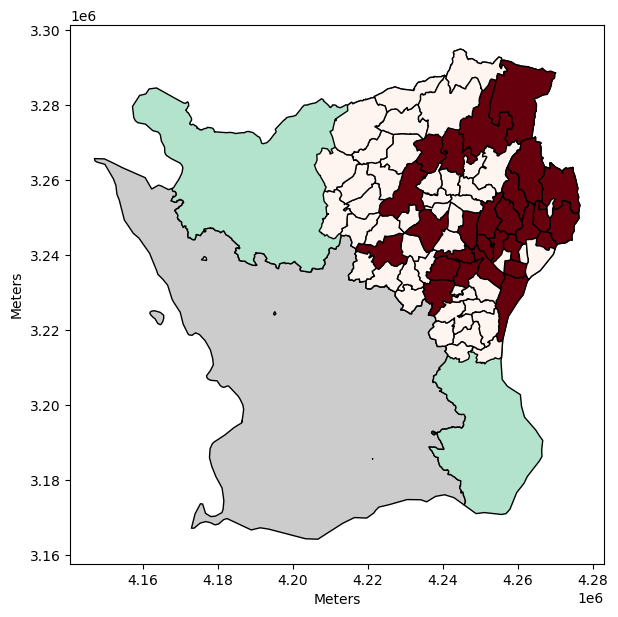

February 29, 2024 February 29, 2024